# **NYC Citi-Bike Ridership & Weather Analysis**

Miles Whiteford & Aaron Gershkovich

[Link to Github Page](https://mileswhiteford.github.io/)

# **Project Goals:**

For this project we want to explore how weather conditions affect Citi Bike ridership in New York City. We are curious about how temperature, precipitation, wind speed, and snow depth impact the number of daily rides. We will also study the bike dataset independently, identifying common travel hubs and ridership patterns by time of day, gender, and user type.

# **Project Datasets**

Source: https://s3.amazonaws.com/tripdata/index.html (2019-citibike-tripdata.zip)

This zip file contains 26 datatsets, each containing per-month citi-bike data, with some months having multiple dataframes. Each dataframe has one row for every citibike ride. This includes 15 columns of information including a description of the ride as well as of the account that took the ride.

**Dataset 2: New York Weather Data** Source: NOAA Global Summary of the Day — Central Park Station  
URL: https://www.ncei.noaa.gov/data/global-summary-of-the-day/access/2019/72505394728.csv

One row per day containing average temperature, precipitation, wind speed, and snow depth for NYC in 2019. We use this to explore how daily weather conditions drive or suppress Citi Bike ridership.

## **1. Imports**

```python
# Mount drive to import datasets
import pandas as pd
import numpy as np
import os
import matplotlib.pyplot as plt
import folium
import branca.colormap as cm
from google.colab import drive
drive.mount('/content/drive')
```

## **2: Import and Clean Datasets**

### Dataset 1: Citi-Bike Data 2019

```python
import pandas as pd
import numpy as np
import os

# Only load from the citibike subfolder, not the whole project folder
base = "/content/drive/MyDrive/Data Science Final Project/2019-citibike-tripdata/"

dfs = []
for root, dirs, files in os.walk(base):
    for f in sorted(files):
        if f.endswith(".csv") and not f.startswith("._"):
            path = os.path.join(root, f)
            df = pd.read_csv(path, low_memory=False)
            dfs.append(df)
            print(f"Loaded {f}: {len(df):,} rows")

# Combine all months into one dataframe
bike_2019 = pd.concat(dfs, ignore_index=True)
bike_2019['starttime']    = pd.to_datetime(bike_2019['starttime'])
bike_2019['stoptime']     = pd.to_datetime(bike_2019['stoptime'])
bike_2019['tripduration'] = bike_2019['tripduration'] / 60

print(f"\nTotal rows: {len(bike_2019):,}")
print(f"Date range: {bike_2019['starttime'].min().date()} → {bike_2019['starttime'].max().date()}")
print(f"Columns: {bike_2019.columns.tolist()}")
print(f"\nMissing values:\n{bike_2019.isnull().sum()}")
```

```
Loaded 201904-citibike-tripdata_1.csv: 1,000,000 rows
Loaded 201904-citibike-tripdata_2.csv: 766,094 rows
Loaded 201912-citibike-tripdata_1.csv: 955,210 rows
Loaded 201911-citibike-tripdata_1.csv: 1,000,000 rows
Loaded 201911-citibike-tripdata_2.csv: 478,708 rows
Loaded 201907-citibike-tripdata_1.csv: 1,000,000 rows
Loaded 201907-citibike-tripdata_2.csv: 1,000,000 rows
Loaded 201907-citibike-tripdata_3.csv: 181,064 rows
Loaded 201910-citibike-tripdata_1.csv: 1,000,000 rows
Loaded 201910-citibike-tripdata_2.csv: 1,000,000 rows
Loaded 201910-citibike-tripdata_3.csv: 92,573 rows
Loaded 201909-citibike-tripdata_1.csv: 1,000,000 rows
Loaded 201909-citibike-tripdata_2.csv: 1,000,000 rows
Loaded 201909-citibike-tripdata_3.csv: 444,900 rows
Loaded 201908-citibike-tripdata_1.csv: 1,000,000 rows
Loaded 201908-citibike-tripdata_2.csv: 1,000,000 rows
Loaded 201908-citibike-tripdata_3.csv: 344,224 rows
Loaded 201906-citibike-tripdata_1.csv: 1,000,000 rows
Loaded 201906-citibike-tripdata_2.csv: 1,000,000 rows
Loaded 201906-citibike-tripdata_3.csv: 125,370 rows
Loaded 201903-citibike-tripdata_1.csv: 1,000,000 rows
Loaded 201903-citibike-tripdata_2.csv: 327,960 rows
Loaded 201901-citibike-tripdata_1.csv: 967,287 rows
Loaded 201902-citibike-tripdata_1.csv: 943,744 rows
Loaded 201905-citibike-tripdata_1.csv: 1,000,000 rows
Loaded 201905-citibike-tripdata_2.csv: 924,563 rows

Total rows: 20,551,697
Date range: 2019-01-01 → 2019-12-31
Columns: ['tripduration', 'starttime', 'stoptime', 'start station id', 'start station name', 'start station latitude', 'start station longitude', 'end station id', 'end station name', 'end station latitude', 'end station longitude', 'bikeid', 'usertype', 'birth year', 'gender']

Missing values:
tripduration                 0
starttime                    0
stoptime                     0
start station id           180
start station name         180
start station latitude       0
start station longitude      0
end station id             180
end station name           180
end station latitude         0
end station longitude        0
bikeid                       0
usertype                     0
birth year                   0
gender                       0
dtype: int64
```

Note: 180 missing entries for station start/end points. Negligible in dataframe that contains over 20 million entries

### Dataset 2: NYC Weather 2019

```python
# Import dataframe
weather_2019 = pd.read_csv("/content/drive/MyDrive/Data Science Final Project/NYC_weather_2019.csv")

# Make everything lowercase
weather_2019.columns = weather_2019.columns.str.lower()

# Convert to date time
weather_2019['date'] = pd.to_datetime(weather_2019['date'])
weather_2019 = weather_2019[weather_2019['date'].dt.year == 2019]

# Rename columns
weather_2019 = weather_2019.rename(columns={
    'temp':'avg_temp_f', 'prcp':'precipitation',
    'wdsp':'wind_speed', 'sndp':'snow_depth'})

# Convert to numeric variables
weather_2019[['avg_temp_f','precipitation','wind_speed','snow_depth']] = \
    weather_2019[['avg_temp_f','precipitation','wind_speed','snow_depth']].apply(pd.to_numeric, errors='coerce')

# Relace missing values with 0
weather_2019['wind_speed']  = weather_2019['wind_speed'].replace(999.9, None)
weather_2019['snow_depth']  = weather_2019['snow_depth'].replace(999.9, None)
weather_2019['precipitation'] = weather_2019['precipitation'].replace(99.99, 0)

print(weather_2019.shape)
weather_2019.head()
```

```
(365, 28)
```

|  | station | date | latitude | longitude | elevation | name | avg_temp_f | temp_attributes | dewp | dewp_attributes | ... | mxspd | gust | max | max_attributes | min | min_attributes | precipitation | prcp_attributes | snow_depth | frshtt |
| --- | --- | --- | --- | --- | --- | --- | --- | --- | --- | --- | --- | --- | --- | --- | --- | --- | --- | --- | --- | --- | --- |
| 0 | 72505394728 | 2019-01-01 | 40.77898 | -73.96925 | 42.7 | NY CITY CENTRAL PARK, NY US | 50.5 | 24 | 43.2 | 24 | ... | 999.9 | 999.9 | 57.9 |  | 36.0 |  | 1.08 | G | None | 10000 |
| 1 | 72505394728 | 2019-01-02 | 40.77898 | -73.96925 | 42.7 | NY CITY CENTRAL PARK, NY US | 38.0 | 24 | 23.2 | 24 | ... | 999.9 | 999.9 | 57.9 |  | 35.1 |  | 0.06 | G | None | 0 |
| 2 | 72505394728 | 2019-01-03 | 40.77898 | -73.96925 | 42.7 | NY CITY CENTRAL PARK, NY US | 41.1 | 24 | 29.4 | 24 | ... | 999.9 | 999.9 | 44.1 |  | 35.1 |  | 0.00 | G | None | 0 |
| 3 | 72505394728 | 2019-01-04 | 40.77898 | -73.96925 | 42.7 | NY CITY CENTRAL PARK, NY US | 39.7 | 24 | 26.4 | 24 | ... | 999.9 | 999.9 | 46.0 |  | 35.1 |  | 0.00 | G | None | 0 |
| 4 | 72505394728 | 2019-01-05 | 40.77898 | -73.96925 | 42.7 | NY CITY CENTRAL PARK, NY US | 44.2 | 24 | 41.0 | 24 | ... | 999.9 | 999.9 | 46.9 |  | 35.1 |  | 0.22 | G | None | 10000 |

5 rows × 28 columns

### Combining the 2 Datasets

```python
# Get total rides per day
daily_rides = bike_2019.groupby(bike_2019['starttime'].dt.date).size().reset_index()

# Rename columns
daily_rides.columns = ['date', 'ride_count']

# Convert date to datetime so it can be merged with weather data
daily_rides['date'] = pd.to_datetime(daily_rides['date'])

# Merge dfs to get weather + total ride stats per day
merged_2019 = pd.merge(daily_rides, weather_2019, on='date', how='inner')

print(f"Rows: {len(merged_2019)}")
merged_2019.head()
```

```
Rows: 365
```

|  | date | ride_count | station | latitude | longitude | elevation | name | avg_temp_f | temp_attributes | dewp | ... | mxspd | gust | max | max_attributes | min | min_attributes | precipitation | prcp_attributes | snow_depth | frshtt |
| --- | --- | --- | --- | --- | --- | --- | --- | --- | --- | --- | --- | --- | --- | --- | --- | --- | --- | --- | --- | --- | --- |
| 0 | 2019-01-01 | 21962 | 72505394728 | 40.77898 | -73.96925 | 42.7 | NY CITY CENTRAL PARK, NY US | 50.5 | 24 | 43.2 | ... | 999.9 | 999.9 | 57.9 |  | 36.0 |  | 1.08 | G | None | 10000 |
| 1 | 2019-01-02 | 37797 | 72505394728 | 40.77898 | -73.96925 | 42.7 | NY CITY CENTRAL PARK, NY US | 38.0 | 24 | 23.2 | ... | 999.9 | 999.9 | 57.9 |  | 35.1 |  | 0.06 | G | None | 0 |
| 2 | 2019-01-03 | 41676 | 72505394728 | 40.77898 | -73.96925 | 42.7 | NY CITY CENTRAL PARK, NY US | 41.1 | 24 | 29.4 | ... | 999.9 | 999.9 | 44.1 |  | 35.1 |  | 0.00 | G | None | 0 |
| 3 | 2019-01-04 | 43922 | 72505394728 | 40.77898 | -73.96925 | 42.7 | NY CITY CENTRAL PARK, NY US | 39.7 | 24 | 26.4 | ... | 999.9 | 999.9 | 46.0 |  | 35.1 |  | 0.00 | G | None | 0 |
| 4 | 2019-01-05 | 17432 | 72505394728 | 40.77898 | -73.96925 | 42.7 | NY CITY CENTRAL PARK, NY US | 44.2 | 24 | 41.0 | ... | 999.9 | 999.9 | 46.9 |  | 35.1 |  | 0.22 | G | None | 10000 |

5 rows × 29 columns

## **3. Summary Stats**

```python
# ── Summary Statistics ────────────────────────────────────────────────────────
import pandas as pd

# Estimate rider age from birth year, filter out unrealistic values (under 16 or over 80)
bike_2019['est_age'] = 2019 - pd.to_numeric(bike_2019['birth year'], errors='coerce')
bike_2019['est_age'] = bike_2019['est_age'].where(
    (bike_2019['est_age'] >= 16) & (bike_2019['est_age'] <= 80))

print("=== CITI BIKE 2019 ===")
display(bike_2019[['tripduration','est_age']].describe().round(2))
# Breakdown by user type (Subscriber vs Customer)
print("\nUser Type:")
display(bike_2019['usertype'].value_counts().to_frame('count'))
#break everything down by gender
print("\nGender:")
display(bike_2019['gender'].map({0:'Unknown',1:'Male',2:'Female'})
        .value_counts().to_frame('count'))

#Print descriptions of all of the weather statistics
print("\n=== WEATHER 2019 ===")
display(weather_2019[['avg_temp_f','precipitation','wind_speed']].describe().round(2))

print(f"\nRain days:  {(weather_2019['precipitation'] > 0.1).sum()} of 365")
print(f"Snow days:  {(weather_2019['snow_depth'].fillna(0) > 0).sum()} of 365")
print(f"Temp range: {weather_2019['avg_temp_f'].min():.1f}°F — {weather_2019['avg_temp_f'].max():.1f}°F")
```

```
=== CITI BIKE 2019 ===
```

|  | tripduration | est_age |
| --- | --- | --- |
| count | 20551697.00 | 20526148.00 |
| mean | 16.30 | 38.73 |
| std | 175.88 | 11.93 |
| min | 1.02 | 16.00 |
| 25% | 6.03 | 29.00 |
| 50% | 10.25 | 36.00 |
| 75% | 17.98 | 49.00 |
| max | 63544.43 | 80.00 |

```
User Type:
```

| usertype | count |
| --- | --- |
| Subscriber | 17679521 |
| Customer | 2872176 |

```
Gender:
```

| gender | count |
| --- | --- |
| Male | 14052393 |
| Female | 4938996 |
| Unknown | 1560308 |

```
=== WEATHER 2019 ===
```

|  | avg_temp_f | precipitation |
| --- | --- | --- |
| count | 365.00 | 365.00 |
| mean | 55.49 | 0.15 |
| std | 17.10 | 0.33 |
| min | 8.40 | 0.00 |
| 25% | 40.60 | 0.00 |
| 50% | 56.60 | 0.00 |
| 75% | 70.80 | 0.12 |
| max | 88.70 | 2.19 |

```
Rain days:  97 of 365
Snow days:  11 of 365
Temp range: 8.4°F — 88.7°F
```

## **4. Graphs and Charts**

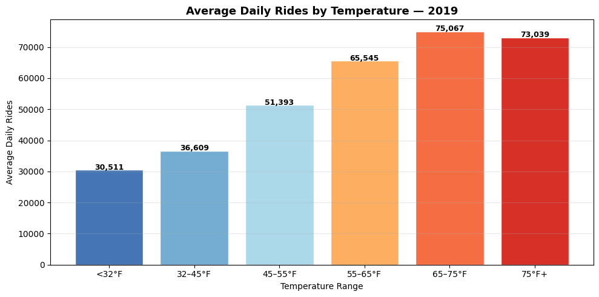

```python
# ── 1. Average Rides by Temperature Bin ──────────────────────────────────────
import matplotlib.pyplot as plt
import pandas as pd
# create mutkliple temperture bins
merged_2019['temp_bin'] = pd.cut(merged_2019['avg_temp_f'],
    bins=[0, 32, 45, 55, 65, 75, 100],
    labels=['<32°F','32–45°F','45–55°F','55–65°F','65–75°F','75°F+'])
#merge temperatures and ride counts by day and agregate the mean
means = merged_2019.groupby('temp_bin')['ride_count'].mean()

#plot them
plt.figure(figsize=(10, 5))
plt.bar(means.index, means.values,
        color=['#4575b4','#74add1','#abd9e9','#fdae61','#f46d43','#d73027'],
        edgecolor='white')
for i, v in enumerate(means.values):
    plt.text(i, v + 100, f'{v:,.0f}', ha='center', fontsize=9, fontweight='bold')
plt.title('Average Daily Rides by Temperature — 2019', fontsize=13, fontweight='bold')
plt.xlabel('Temperature Range')
plt.ylabel('Average Daily Rides')
plt.grid(axis='y', alpha=0.3)
plt.tight_layout()
plt.show()
```

Warmer days see significantly more rides as days above 75°F have more rides than days below freezing, showing a clear positive relationship between temperature and ridership.

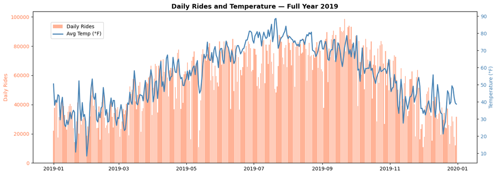

```python
# ── Rides and Temperature Throughout 2019 ─────────────────────────────────────
fig, ax1 = plt.subplots(figsize=(14, 5))

#merge based on date and ride count
ax1.bar(merged_2019['date'], merged_2019['ride_count'],
        color='coral', alpha=0.6, label='Daily Rides')
ax1.set_ylabel('Daily Rides', color='coral')
ax1.tick_params(axis='y', labelcolor='coral')

#graph the average temperatures
ax2 = ax1.twinx()
ax2.plot(merged_2019['date'], merged_2019['avg_temp_f'],
         color='steelblue', linewidth=2, label='Avg Temp (°F)')
ax2.set_ylabel('Temperature (°F)', color='steelblue')
ax2.tick_params(axis='y', labelcolor='steelblue')

plt.title('Daily Rides and Temperature — Full Year 2019', fontweight='bold', fontsize=13)
fig.legend(loc='upper left', bbox_to_anchor=(0.1, 0.88))
plt.tight_layout()
plt.show()
```

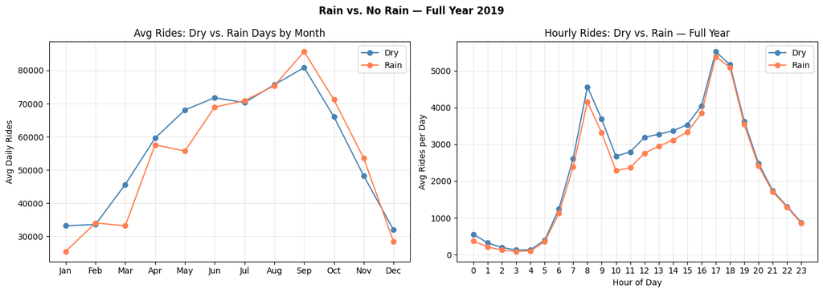

```python
# ── 2. Dry vs Rain ────────────────────────────────────────────────────────────
import matplotlib.pyplot as plt
import pandas as pd

#Normalize the the start time, and find the hour of time.
bike_2019['date'] = bike_2019['starttime'].dt.normalize()
bike_2019['hour'] = bike_2019['starttime'].dt.hour
#Merge based on date information
bike_wx = pd.merge(bike_2019, merged_2019[['date','precipitation']], on='date', how='inner')
bike_wx['is_rain'] = bike_wx['precipitation'] > 0.1

#create a rain if the percipitation is above 0.1
merged_2019['is_rain'] = merged_2019['precipitation'] > 0.1
merged_2019['month']   = merged_2019['date'].dt.month
#calculate means of both
dry  = merged_2019[~merged_2019['is_rain']].groupby('month')['ride_count'].mean()
rain = merged_2019[ merged_2019['is_rain']].groupby('month')['ride_count'].mean()

#graph everything
fig, (ax1, ax2) = plt.subplots(1, 2, figsize=(14, 5))

ax1.plot(dry.index,  dry.values,  color='steelblue', marker='o', label='Dry')
ax1.plot(rain.index, rain.values, color='coral',     marker='o', label='Rain')
ax1.set_xticks(range(1,13))
ax1.set_xticklabels(['Jan','Feb','Mar','Apr','May','Jun','Jul','Aug','Sep','Oct','Nov','Dec'])
ax1.set_ylabel('Avg Daily Rides')
ax1.set_title('Avg Rides: Dry vs. Rain Days by Month')
ax1.legend(); ax1.grid(True, alpha=0.3)

for is_rain, label, color in [(False,'Dry','steelblue'),(True,'Rain','coral')]:
    sub    = bike_wx[bike_wx['is_rain'] == is_rain]
    hourly = sub.groupby('hour').size() / sub['date'].nunique()
    ax2.plot(hourly.index, hourly.values, color=color, marker='o', label=label)
ax2.set_xlabel('Hour of Day'); ax2.set_ylabel('Avg Rides per Day')
ax2.set_title('Hourly Rides: Dry vs. Rain — Full Year')
ax2.set_xticks(range(0,24)); ax2.legend(); ax2.grid(True, alpha=0.3)

plt.suptitle('Rain vs. No Rain — Full Year 2019', fontweight='bold')
plt.tight_layout(); plt.show()
```

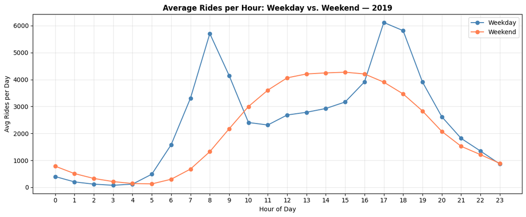

```python
# ── 3. Weekday vs Weekend ─────────────────────────────────────────────────────
import matplotlib.pyplot as plt
#create an weekend set
bike_2019['hour']       = bike_2019['starttime'].dt.hour
bike_2019['is_weekend'] = bike_2019['starttime'].dt.dayofweek >= 5

#number of unique rides in each group
n_wd = bike_2019[~bike_2019['is_weekend']]['starttime'].dt.date.nunique()
n_we = bike_2019[ bike_2019['is_weekend']]['starttime'].dt.date.nunique()

#group by hour
wd = bike_2019[~bike_2019['is_weekend']].groupby('hour').size()
we = bike_2019[ bike_2019['is_weekend']].groupby('hour').size()

plt.figure(figsize=(12, 5))
plt.plot(wd.index, wd.values/n_wd, color='steelblue', marker='o', label='Weekday')
plt.plot(we.index, we.values/n_we, color='coral',     marker='o', label='Weekend')
plt.xlabel('Hour of Day')
plt.ylabel('Avg Rides per Day')
plt.title('Average Rides per Hour: Weekday vs. Weekend — 2019', fontweight='bold')
plt.xticks(range(0, 24))
plt.legend()
plt.grid(True, alpha=0.3)
plt.tight_layout()
plt.show()
```

```python
# ── 4. Top Stations Interactive Map ──────────────────────────────────────────
import folium
import branca.colormap as cm
import pandas as pd

#insert top information by grouping the top 50 total rides
top_stations = (bike_2019
    .groupby(['start station name','start station latitude','start station longitude'])
    .size().reset_index(name='total_rides')
    .sort_values('total_rides', ascending=False).head(50))

#create a color legent based on how popular they are
colormap = cm.LinearColormap(
    colors=['#4575b4','#91bfdb','#fee090','#fc8d59','#d73027'],
    vmin=top_stations['total_rides'].min(),
    vmax=top_stations['total_rides'].max(),
    caption='Total Rides 2019')

m = folium.Map(location=[40.752, -73.977], zoom_start=13, tiles='CartoDB positron')

for _, row in top_stations.iterrows():
    folium.CircleMarker(
        location=[row['start station latitude'], row['start station longitude']],
        radius=10, color='white', weight=1,
        fill=True, fill_color=colormap(row['total_rides']), fill_opacity=0.85,
        tooltip=f"<b>{row['start station name']}</b><br>{row['total_rides']:,} rides"
    ).add_to(m)

colormap.add_to(m)
from IPython.display import display
display(m)
```

Make this Notebook Trusted to load map: File -> Trust Notebook

[interactive chart not shown]

This provides an insight into which ports have the highest usage which could impact decisions on weathering certain conditions in order to use bikes especially when other options are not available.

# **Proposed Model Questions**

**Model 1: Can daily weather conditions predict daily Citi Bike ridership?**

- **Type:** k Nearest Neighbors Model
- **Independent Variables (X):** Average temperature, precipitation, wind speed, snow depth, day of the week
- **Dependent Variable (Y):** Total daily ride count
- **Hypothesis:** Temperature will be the strongest positive predictor, while precipitation and snow will be negative predictors

**Model 2: Is there a statistically significant difference in trip duration between Subscriber and Customer riders?**

- **Type:** Two-sample t-test
- **Independent Variable:** User type (Subscriber vs. Customer)
- **Dependent Variable:** Trip duration in minutes
- **H₀:** No significant difference in average trip duration between user types
- **H₁:** Customers take significantly longer trips than Subscribers

# **Collaboration Plan**

We are using a shared Google Colab notebook in Google Drive so we can both work on the code at the same time. We meet 2 times a week in the library to go over what we have done, split up tasks, and make sure we are on the same page. Before Milestone 2 we want to finish cleaning both datasets, get our five summary stats computed, and have the first draft of our time series charts ready. After that we will focus on deeper analysis, better visualizations, and putting together the final presentation. We really want to maximize time spent working together to ensure we are on the same page and contribute equally to this assignment